# Regression Discontinuity

- Show All Code
- Hide All Code

Module 7.1: Basics

Author

Affiliation

Alex Cardazzi

Old Dominion University

All materials can be found at [alexcardazzi.github.io](https://alexcardazzi.github.io/econ708.html).

## Regression Discontinuity

In this final module, we will discuss Regression Discontinuity Design (“RD” or “RDD”). As a bit of a peak behind the curtain, these modules have been ordered from easiest to hardest (in my opinion) to find “in the wild.” By this, I mean that it’s usually easier for people to come up with a setting for DiD compared to IV, which may have become apparent in the imagination exercises. Knowing this, you might consider RDD to be the most difficult design to pull off. In some ways, this is true, but the intuition behind RDD is fairly simple and the method is regarded by many to be the most credible causal inference design (aside from an RCT, of course).

### Flagship Universities

Let’s once again motivate this methodology with an example from a published paper. Human capital accumulation, via educational attainment, is an often studied determinant of labor market outcomes and quality of life. Perhaps a more interesting question is the effect of school choice on these same outcomes. In particular, what are the returns to attending a state’s “flagship” university? In [a 2009 paper in *The Review of Economics and Statistics*](https://www.jstor.org/stable/25651372), Mark Hoekstra examines this very question. Reading through this paper as you work through these notes might prove to be a useful exercise (and it’s less than 10 pages).

For context, the “flagship university” in Virginia is UVA. Hoekstra’s paper was published in 2009, three years after completing his PhD at University of Florida. Since Hoekstra used actual college admissions data from the examined flagship, we can make an educated guess at which flagship university gave him the data.

To address the question of returns to attending the flagship, let’s think through the other approaches we’ve learned thus far. First, students are not randomly assigned to colleges and universities, so we cannot simply estimate a model with an indicator for attending the flagship like we would in an RCT. Second, this type of question would not be a case study, so we can quickly rule out synthetic control. Third, we could think about DiD or Matching. With matching, we could look at the subset of students admitted into the flagship university, and compare the outcomes of those who attended the school to the outcomes of those who did not. An issue with IPW or PSM is that, conditional on acceptance, there are likely some unobservable factors that causes both student outcomes and the decision to attend the flagship.[^1] DiD also presents a challenge due to a lack of a pre-period. Without pre-treatment earnings, we cannot measure pre-post differences.

The most recent method we discussed, IV, would be an interesting way to address this question. To do so, we would need some instrument that causes college admission/attendance that is uncorrelated with earning potentials. David Card, in 1993, used proximity to college as an instrument for attending college and found positive returns to schooling. In this paper, Card is estimating the extensive margin (college vs no college). However, this does not really get at the intensive margin: the returns to attending a relatively more selective college (as proxied by flagship status).

Before getting into how Hoekstra addressed this question, we need to understand the admission decision rule for the university. Each student’s highschool GPA corresponds to a particular SAT score needed for admission. For example, a student with a 3.0 might need a 1,000 SAT, but a student with a 2.9 GPA might need a 1,100 SAT. Each student is then awarded points based on how different their SAT was from the required SAT. If the 2.9 student scored a 1,150 on their SAT, they would be given 50 points. If the 3.0 student scored 1,150, they would be awarded 150 points. Only students with non-negative amounts of points were admitted into the university.

This “score” determines admission into the flagship, which would be the treatment in this case. However, individuals barely to the right of the cutoff are probably similar to those barely to the left. In fact, the only difference between students with a score of -10 and +10 is a question or two on the SAT. These students are practically the same, but the small difference in their SAT scores earns one of them admission into the flagship university.

In short, Hoekstra takes advantage of this setup by examining earning outcomes for students right around this cutoff to estimate the causal treatment effect of being admitted into the state’s flagship university. Before getting into the nitty gritty, let’s define some terms.

- **Running Variable**: this is the measure that partially determines treatment. In our example, the SAT score would be the running variable.
- **Cutoff**: this is the *value* of the running variable that determines treatment. Since the SAT scores have been adjusted to be centered at zero, depending on the GPA, zero is the cutoff in the example. As another example, when studying retirement, 65 would be a cutoff value and age the running variable.
- **Bandwidth**: this is the maximum distance from the cutoff you are willing to consider observations “similar”. You may be willing to consider students $\pm 100$ points away from the cutoff similar, but students $\pm 200$ points away from the cutoff less than comparable.

Both a continuous running variable and a clearly defined cutoff are absolutely necessary to estimate regression discontinuity designs.

### Assumptions

Much like how IV requires excludability and validity, while DiD requires parallel trends, there are two main assumptions in RDDs. These assumptions ensure the treatment is plausibly exogenous, or effectively randomly assigned.

First, individuals close to the cutoff should be similar in both their observable and unobservable characteristics. In other words, the *only* thing that changes at the cutoff is treatment, and individuals are identical otherwise. In the case of SAT scores and admissions, a few more correct (incorrect) questions on the SAT is hardly a meaningful difference in terms of student quality.

Second, individuals may not manipulate their being on either side of the cutoff. A violation of this assumption is a clear indication of non-random treatment assignment. Typically, it’s best if the individuals do not even know about the cutoff, because then manipulation is impossible. In the case of admissions, the SAT cutoff was unknown to students. If it were known, the students could have kept taking the SAT until they got their desired score on the test for admission.

*If* both of these assumptions are met, RDD is often considered the best you can do without having an RCT.

/

[video not shown]

### Sharp RDD

Let’s suppose that being above the SAT threshold for your GPA automatically guaranteed admission into the university. Further, once admitted, students decided to enroll in the university 100% of the time. While this is certainly unrealistic in this setting (since both students and admissions offices have free will), this is the case for some things, like government policies.

For example, during the pandemic, the government gave out stimulus checks. If they decided to only give out stimulus checks to individuals who made less than $75,000 in 2019, this would fit the setting outlined above. In this case, the running variable would be 2019 income, and the cutoff would be $75,000. People making $77,000 are probably similar to people making $73,000. Also, since the stimulus checks were given out based on (predetermined) pre-pandemic income, which side of the cutoff people fall on is not manipulable.

If we wanted to estimate the effect of stimulus checks on some outcome $Y$ in this setting, we could model it explicitly as follows:

$$Y = \beta_0 + \beta_1 (\text{Running - Cutoff}) + \beta_2 [(\text{Running - Cutoff})\times D] + \beta_3 D + \epsilon$$

where $D$ is equal to $1$ when the running variable takes on a value greater than the cutoff.

$\beta_0$ represents the intercept, or the expectation of $Y$ when all other variables are equal to zero. $\beta_1$ controls for the relationship between the running variable and $Y$ *before* the cutoff, whereas $\beta_2$ controls for the relationship between the running variable and $Y$ *after* the cutoff. In other words, we are fitting two different lines before and after the cutoff value. $\beta_3$ represents the parameter of interest – the effect of moving from the not treated group to the treated group. Of course, you may want other controls in this model, but this would be the most basic set up.

The idea of including the centered running variable interacted with the treatment variable is to control for potentially different relationships between the running variable and the outcome on either side of the cutoff. However, the direct interpretation of $\beta_2$ is the *change* in the relationship when moving from one side of the cutoff to the other. Therefore, to the effect of the running variable on the outcome on the left of the cutoff is $\beta_1$. The effect of the running variable on the outcome on the right of the cutoff is $\beta_1 + \beta_2$.

Note that in this model, we are assuming a linear fit on either side of the cutoff. In more modern applications, econometricians tend to use more flexible (i.e. complicated) methods to estimate the relationships on either side of the cutoff. We will demonstrate some of this in the programming section of the notes, but it’s important to realize that this linear approximation is mostly for instructional purposes. For example, we could instead use a quadratic fit, or some other functional form. Remember, our primary interest is estimating/interpreting the change in the outcome at the cutoff. Therefore, how we estimate the pre- and post- cutoff relationships between the running variable and outcome is only important insofar that we can appropriately fit the data around the cutoff. More on this later.

### Fuzzy RDD

Hoekstra’s paper about college admissions is a bit unlike the hypothetical case regarding stimulus checks. Admission decisions are influenced by GPA and SAT scores, but also extra curricular activities and extraordinary circumstances. In addition, college students often get admitted to more than one school, so the probability that an admitted student enrolls in any given university is less than one. All of this is to say that students below the cutoff may still enroll in the flagship university, and students above the cutoff may choose to not enroll. Therefore, being above or below the cutoff does not perfectly determine treatment status, but it should still significantly increase the probability of treatment.

This should sound a lot like an instrumental variable. Remember, being drafted into the military did not perfectly determine military status, but it did significantly influence the probability of enlistment. We are going to treat the running variable and cutoff as an instrument in cases like this. Therefore, we need a two-stage estimation procedure, just like IV.

The first-stage would be to estimate treatment, or enrollment, via the cutoff:

$$\text{Enroll} = \alpha_0 + \alpha_1 (\text{Running - Cutoff}) + \alpha_2 [(\text{Running - Cutoff})\times D] + \alpha_3 D + \epsilon$$

Once we gather the fitted values for enrollment ($\widehat{Enroll}$), we can plug those values into the second stage as follows:

$$Y = \beta_0 + \beta_1 (\text{Running - Cutoff}) + \beta_2 [(\text{Running - Cutoff})\times D] + \beta_3 \widehat{\text{Enroll}} + \epsilon$$

Here, our parameter of interest is represented by $\beta_3$ once again. Note that we still control for the pre- and post-cutoff relationships between the running variable and the outcome. Of course, all of the previous discussion about this being a linear fit still applies.

### Bandwidth Selection

Regardless of whether we choose either a sharp or fuzzy design, it’s important to consider the sample we use to estimate our treatment effect. Specifically, there’s still the question of bandwidth. Choosing a too-large bandwidth will increase the sample size (thus the statistical power and/or precision) but also increases the risk of bias. The additional observations that get let in towards the edges of the bandwidth are less likely to be similar and could introduce confounding. On the other hand, choosing a too-small bandwidth will reduce the risk of bias, but also reduce the sample size and thus accuracy of the estimates.

There are many different ways to select a bandwidth, though we will eventually have R do this for us. However, the most intuitive approach to selecting a bandwidth is simply choosing something “reasonable” with respect to the empirical setting. Then, we can vary the bandwidth to test the sensitivity of the estimate to our choice of bandwidth. In applications, this can be done by continually re-estimating the model inside of a `for` loop and collecting the results.

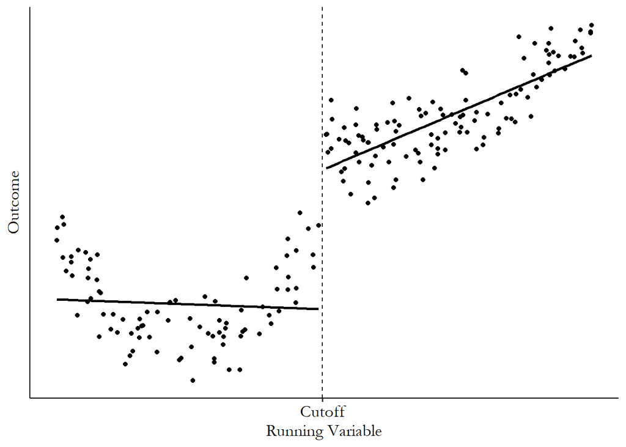

Linear, no bandwidth

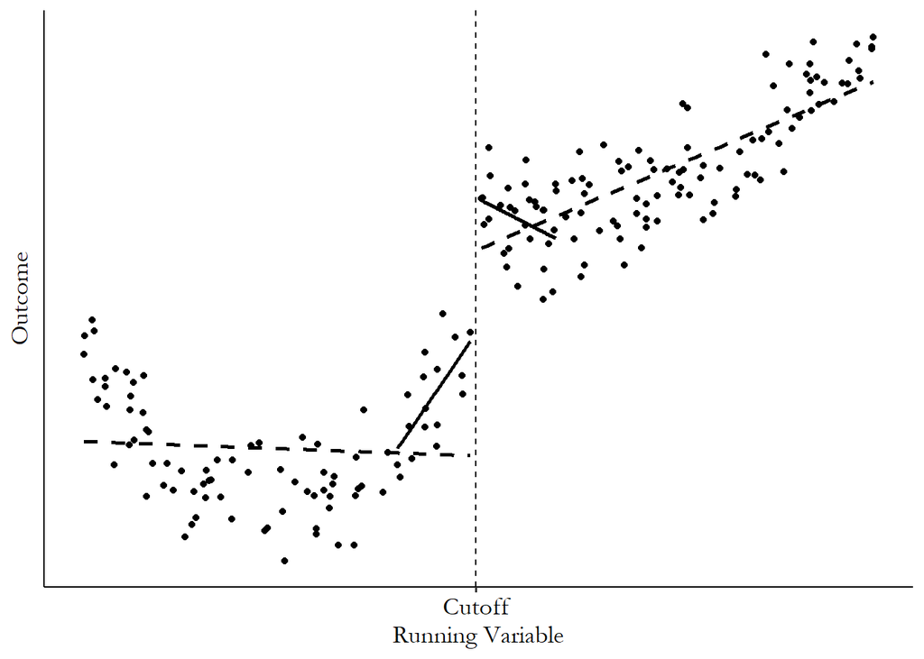

Linear, with bandwidth

The figures above are taken from NHK’s textbook chapter and demonstrate the effects of bandwidth choice. In the figure to the left, no bandwidth is used, and thus all of the observations are included in the estimation. This figure also demonstrates the consequences of using only linear fits. The treatment effect would be the vertical distance between the two solid lines at the cutoff value. In this figure, the treatment is clearly exaggerated by the poor fit of the linear model.

In the figure to the right, the fit of the linear model is improved by the use of a bandwidth. Even though the data clearly exhibit a non-linear relationship over the domain of the running variable, linear approximations work just fine right around the cutoff.

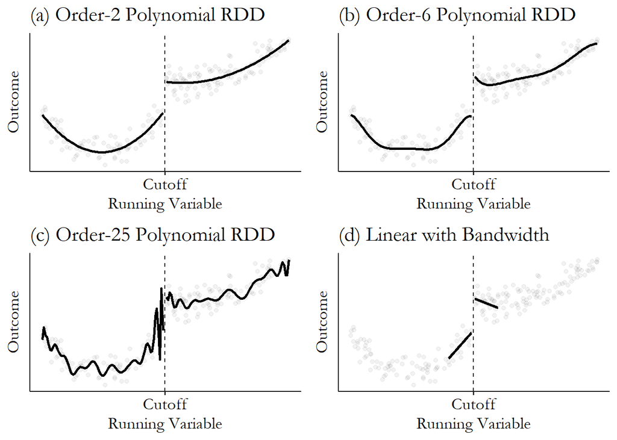

Different Ways to Fit

In the above series of figures, NHK ditches the bandwidth in favor of more flexible functional forms. In the first panel, NHK uses a quadratic fit on either side of the cutoff, and the treatment effect looks similar to that of the linear fit with a bandwidth. In the second panel, he uses an order-6 polynomial (i.e. $\alpha_6x^6 + \alpha_5x^5 + ... + \alpha_1x + \alpha_0$) which does a better job of fitting the data but does not really add much to the estimation of the cutoff. In the third panel, he uses an order-25 polynomial which, at this point, *overfits* the data. In other words, this model is picking up patterns that do not actually exist. The fourth panel exists as a reference.

These figures provide visual evidence of ways to use either complicated models or bandwidths to estimate RDDs. In practice, though, we will use both simultaneously.

[video not shown]

## Coding

In this section, we are going to analyze a pretend policy implemented by ODU. Let’s suppose that on the first day of freshman year, every student had to take a general college readiness exam. The purpose of this exam is to identify students who might need some extra help as they begin their college career. ODU then *forces* students to use a tutor if and only if they score below a 70 on this exam. Students are then given a second exam immediately before graduation to test how much they’ve learned.

ODU has prompted us with measuring how much tutoring can improve test scores. Since we observe treatment being determined by some rule, we can explore using RDD. There are four steps we need to take:

1. Determine if our RDD is sharp or fuzzy.
2. Check for manipulation around the cutoff.
3. Check for a discontinuity at the cutoff in the outcome.
4. Estimate the discontinuity.

The figures below demonstrate these four steps.

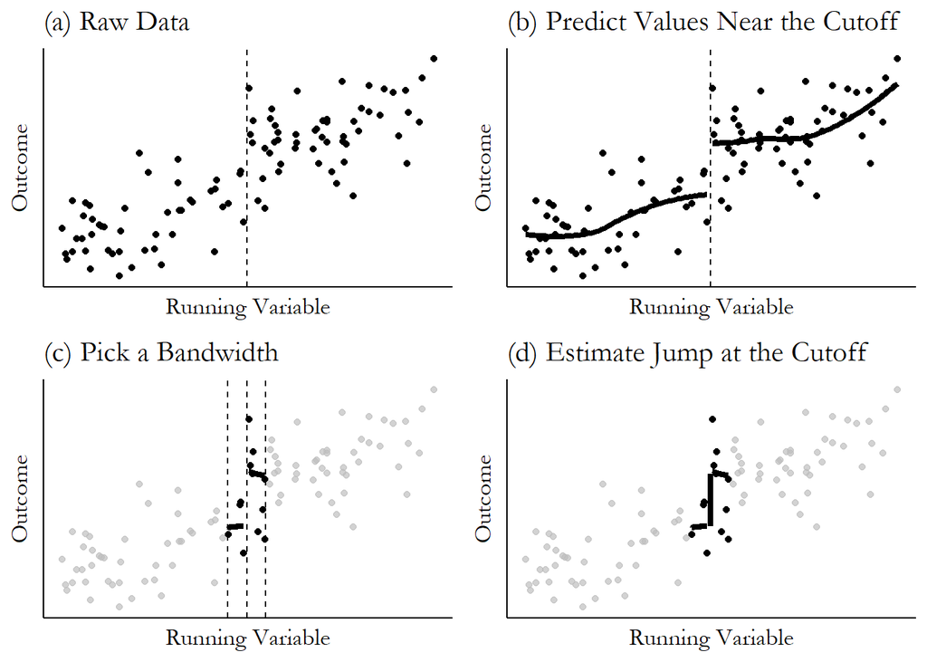

### Sharp vs Fuzzy

First, we need to determine whether our RDD is sharp or fuzzy. Remember, if the cutoff determines treatment *with certainty*, then we should use a sharp RDD. Otherwise, fuzzy is the way to go.

Since ODU enforces tutoring for *all* students who scored below a 70 in this hypothetical case, we would conclude this to be a sharp regression discontinuity. If tutoring was instead available to all, but only suggested/advertised to students who scored below 70 on their exam, this would be a fuzzy regression discontinuity.

## Sharp vs Fuzzy

The default arguments generate data consistent with a sharp regression discontinuity since `PROB` is set to 1. If this were a number between 0 and 1, the data would be consistent with a fuzzy design.

### Cutoff Manipulation

Next, we need to check the assumption that individuals are not manipulating their being on a specific side of the cutoff. There are formal statistical tests for this, but the intuition is simple. If the distribution along the running variable appears continuous at the cutoff, then our assumption holds. If there is manipulation, we should see a distribution mass on one side of the cutoff. We need to check the distribution of the running variable as well as any other controls.

An example of a distribution that is *clearly* manipulated is the distribution of marathon finishing times. See below for this distribution.

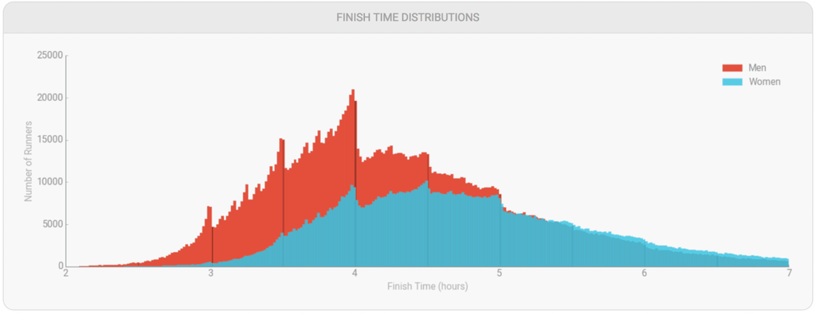

## Cutoff Manipulation

Depending on the data that was generated, you might get a figure that makes it look like there’s some manipulation going on. However, if you increase the sample size of the generated data, this should eventually wash away. What if we don’t have the luxury of simply increasing our sample size? We need a statistical test to help us.

If our statistical test suggests that there is no manipulation, then we can proceed with our analysis.

### Discontinuity

The penultimate step is to visually check for a discontinuity in the outcome variable. To do this, generate a plot where the running variable is on the x-axis and the outcome is on the y-axis. Note that in some cases, you can use a simple scatter plot. However, with a lot of data, you might want to use aggregate to make the figure more concise.

Note that while we want to see a discontinuity in the outcome variable, we *do not* want to see any discontinuities in any other observable variables, as this suggests evidence of confounding and/or manipulation at the cutoff.

### Estimation

Finally, we can estimate the treatment effect, which is the change in the outcome variable right at the cutoff value. To illustrate, we will first estimate the cutoff *parametrically* using a sharp design followed by a fuzzy design. Next, we’ll use the `rdrobust` package to estimate the discontinuity with *nonparametric* methods.

“Parametric” means that we are imposing a functional form onto the model. For example, $Y = \alpha + \beta X$ is *parameterized* with a slope and intercept. A nonparametric model is something that does not have a particular functional form, and is therefore more flexible. Using a parametric model trades off accuracy for interpretability. However, in RDD, economists hardly ever interpret the relationship between the running variable and the outcome, so they elect for accuracy. Ultimately, this allows for a more accurate and interpretable estimate of the treatment effect.

First, we need to create an additional variable to help us in the estimation procedure. Specifically, we’ll create a centered running variable. In other words, the running variable minus the cutoff. Once we have this variable, we can estimate our RD. Remember, we are initially estimating a sharp regression discontinuity. Our first model will include the running variable and the tutor indicator. The assumption we are making in doing this is that an additional point scored on the first exam will have the same effect for students on either side of the cutoff. Is this assumption reasonable? Probably, but it is an assumption that we do not really need to make. Instead, we can interact the two variables in the model, which will allow the relationship to change on either side of the cutoff.

**Table of Estimates**

```r
r1 <- lm(exam2 ~ centered + tutor, df)
r2 <- lm(exam2 ~ centered*tutor, df)

library("modelsummary")
options(modelsummary_factory_default = 'tinytable')
options("modelsummary_format_numeric_latex" = "plain")

regz <- list(`(1)` = r1, `(2)` = r2)
coefz <- c("centered" = "Centered Exam 1 Score",
           "tutor" = "Tutoring",
           "centered:tutor" = "Centered Exam 1 Score x Tutoring",
           "(Intercept)" = "Constant")
gofz <- c("nobs", "r.squared")
modelsummary(regz,
             title = "Effect of Tutoring on Exam 2 Scores",
             estimate = "{estimate}{stars}",
             coef_map = coefz,
             gof_map = gofz)
```

**Display Output**

Effect of Tutoring on Exam 2 Scores

|  | (1) | (2) |
| --- | --- | --- |
| Centered Exam 1 Score | 0.539*** | 0.522*** |
|  | (0.027) | (0.032) |
| Tutoring | 10.288*** | 10.493*** |
|  | (0.833) | (0.862) |
| Centered Exam 1 Score x Tutoring |  | 0.053 |
|  |  | (0.057) |
| Constant | 59.484*** | 59.711*** |
|  | (0.436) | (0.500) |
| Num.Obs. | 1000 | 1000 |
| R2 | 0.315 | 0.316 |

In the table, the first coefficient in the first column is an estimate of the linear relationship between the student scores on exam 1 and the scores on exam 2. The second estimate represents the effect of tutoring on exam scores, which is our treatment effect.

These estimates were generated using a different instance of simulated data, which might not match what you are working with in the WebR chunks.

In the second column, the first estimate is the relationship between exam 1 and exam 2 for students who did not get tutoring. In other words, the relationship when exam 1 was above the cutoff. Therefore, the relationship between exam 1 and exam 2 for students below the cutoff is the sum of the first and third parameters. Interpreting these coefficients is similar to interpreting interactions in a DiD setup. Finally, the second estimate is, once again, our causal treatment effect.

As a note before we move onto estimating a fuzzy design, we can also apply bandwidths to our sample to eliminate observations that are far from the cutoff. To apply a bandwidth, we can simply use the `subset` argument in `lm()`. In particular, to keep only students who scored within 10 points of the cutoff on the exam, we can use `lm(..., subset = abs(df$centered) <= 10)`. Try this out in the previous code chunk.

In the following, we will use `rdrobust()` from the package `rdrobust`. Sometimes using packages can feel particularly like a black box, and I am sympathetic to that feeling. It may be helpful to keep in the back of your mind that the code below is simply performing a beefed up version of the routines we used above.

It’s often important to examine the treatment effect estimate’s sensitivity to the choice of bandwidth. To address this, we can manually vary the bandwidth by using the `h` argument in `rdrobust()`. A good way to check is by halving and doubling the bandwidth and re-estimating the model. Give this a try in the following chunk:

To turn this from a sharp RDD to a fuzzy design, we only need to make a small tweak. Specifically, we would simply supply the treatment variable inside the function: `fuzzy = df$tutor`. Try estimating a fuzzy RD using function above again with data generated using `PROB = 0.8`.

## Back to Flagships

RDD is relatively simple to estimate, convincing *and* intuitive. Again, besides RCTs, this is the gold standard of causal inference research designs. However, finding settings “in the wild” where one can use RDD is often difficult and sometimes a matter of luck. So, before concluding, let’s finish up our discussion of Hoekstra and flagship universities.

Hoekstra uses a fuzzy regression discontinuity design because the cutoff does not perfectly predict enrollment. However, he finds that the probability of enrollment jumps up by almost 40 percentage points for students immediately to the right of the SAT cutoff. So, it’s clear that the cutoff plays a significant role in admission decisions. Hoekstra also checks for manipulation at the cutoff but does not find any evidence.

In the second part of the analysis, Hoekstra estimates the discontinuity in the natural log of earnings for the students in the sample. After applying the fuzzy RDD, he finds about a 13% increase in earnings due to admission, and a 22% increase in earnings due to enrollment. Of course, this raises questions about why/how this is. Unfortunately, Hoekstra is unable to answer these questions given the data, but this certainly opens up avenues for future research.

## NHK Videos

[video not shown]

/

[video not shown]

## Footnotes

[^1]: In fact, some previous research has tried to mitigate these concerns by using pairs of twins who choose to attend different universities.